# Assignment 7

2022-06-28

```r
##install.packages("RCurl")
##install.packages("XML")
##install.packages("rvest")
library(rvest)
library(XML)
library(RCurl)
library(tidyverse)
library(dplyr)
```

Loading the HTML file data in R environment

```r
#Load the data from HTML to r
data <- read_html("https://en.m.wikipedia.org/wiki/List_of_countries_by_percentage_of_population_living_in_poverty")
class(data)
```

```
## [1] "xml_document" "xml_node"
```

```r
html <- data %>% html_table(., fill = TRUE ,trim = TRUE)

data1 <- html[[2]]
```

Q 1 - Scrape the data from the webpage and extract the following fields: Country, < $1.90, < $3.20, < $5.50, Year and Continent. Prepare the data for analysis and ensure that the columns have meaningful names.

```r
## counting NA rows
sum(is.na(data1))
```

```
## [1] 0
```

```r
unique(data1$Continent)
```

```
## [1] "Europe"        "Africa"        "South America" "Asia"
## [5] "Oceania"       "North America" "Asia, Europe"
```

```r
## no missing value available
## renaming and mutating the columns to prepare for analysis
data2 <- data1 %>%
  rename(
    lessthan_1.90 = "< $1.90[8][1]",
    lessthan_3.20 = "< $3.20[6]",
    lessthan_5.50 = "< $5.50[7]"
    )


## data ready for analysis

data3 <- data2 %>% mutate('lessthan_1.90' = as.numeric(sub("%", "", data2$lessthan_1.90, fixed = TRUE)),
                                        'lessthan_3.20' = as.numeric(sub("%", "", data2$lessthan_3.20, fixed = TRUE)),
                                        'lessthan_5.50' = as.numeric(sub("%", "", data2$lessthan_5.50, fixed = TRUE)),
                                        'Year' = as.numeric(data2$Year))
```

Q2 - Calculate the mean and the standard deviation of the percent of the population living under $5.50 per day for each continent. Perform a comparative analysis (i.e. explanation) of the data from each continent.

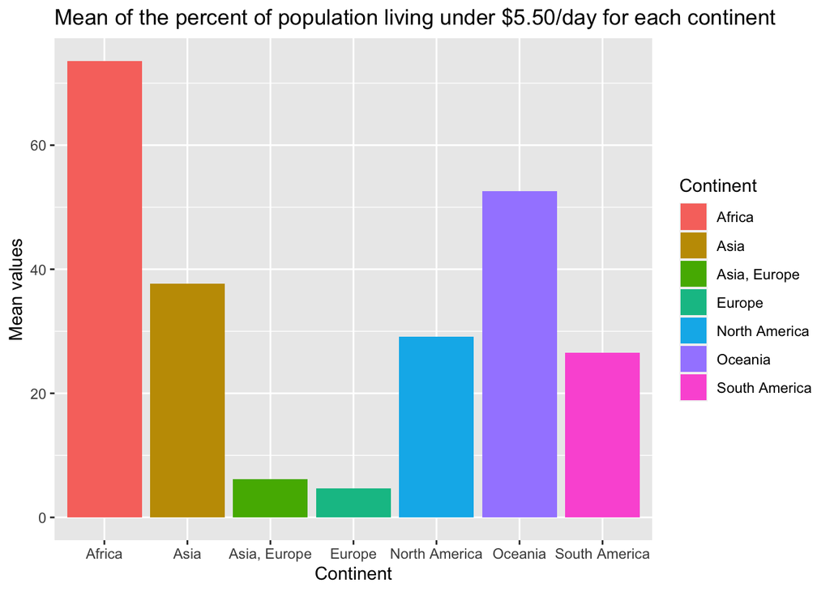

```r
## create new data_frame with mean and standard deviation of the percent of the population living under $5.50 per day for each continent
q2_data <- data3 %>% select(-lessthan_1.90, -lessthan_3.20, -Year, -Country) %>%
  group_by(Continent) %>% summarise(mean = mean(as.numeric(lessthan_5.50)), standard_deviation = sd(as.numeric(lessthan_5.50)))
## visualizing the data with mean of the population living under $5.50/day by grouping continents
ggplot(q2_data, aes(Continent, mean, fill = Continent)) +
  geom_bar(stat = "identity") +
  ggtitle("Mean of the percent of population living under $5.50/day for each continent") +
  labs(x = "Continent", y = "Mean values")
```

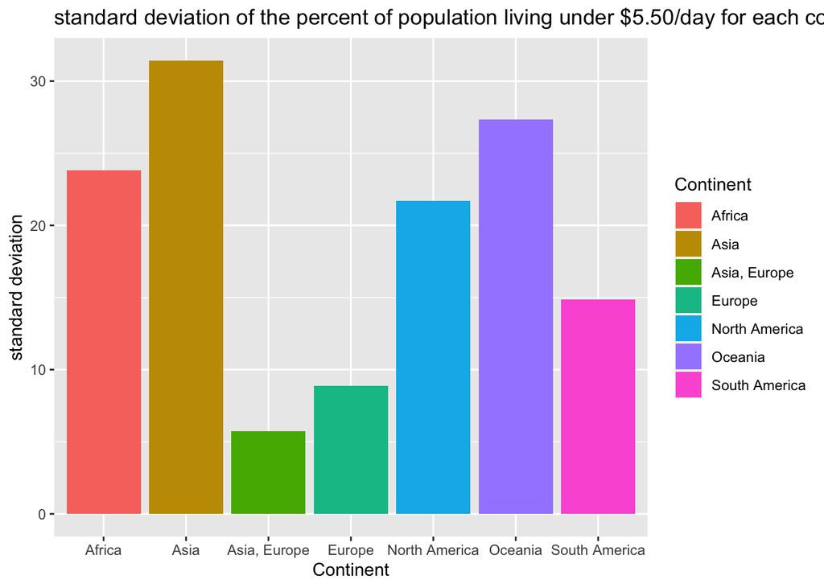

```r
## visualizing the data with standard deviation of the population living under $5.50/day by grouping continents
ggplot(q2_data, aes(Continent, standard_deviation, fill = Continent)) +
  geom_bar(stat = "identity") +
  ggtitle("standard deviation of the percent of population living under $5.50/day for each continent") +
  labs(x = "Continent", y = "standard deviation")
```

```r
sum(is.na(q2_data))
```

```
## [1] 0
```

Q3 - What are the 10 countries with the highest percentage of the population having an income of less than $5.50 per day? Using a suitable chart, display the country name, the percentage and  
color- code by the Continent. Summarize your findings.

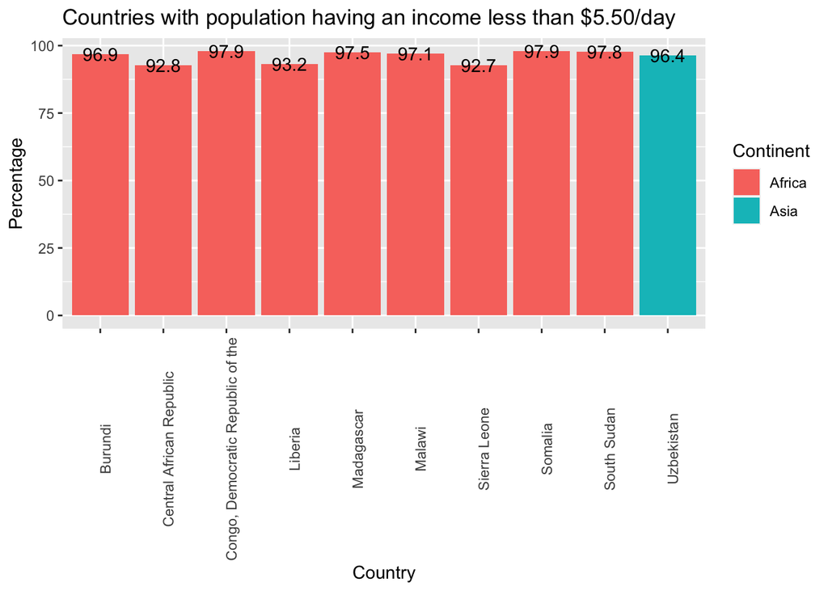

```r
## Create q3_data with 10 countries with the highest percentage of the population having an income of less than $5.50 per day.
q3_data <- data3 %>% select(Country,lessthan_5.50, Continent) %>% arrange(desc(lessthan_5.50))
q3_data <- head(q3_data, n = 10)

## visualize the data using bar chart
ggplot(q3_data, aes(Country, lessthan_5.50, fill = Continent)) +
  geom_bar(stat = "identity") +
  theme(axis.text.x = element_text(angle = 90)) +
  ggtitle("Countries with population having an income less than $5.50/day") +
  labs(x = "Country", y = "Percentage") +
  geom_text(aes(label = lessthan_5.50))
```

```r
##Most of the countries with the highest percentage of the population having an income less than 5.50/day are from Africa continent. The highest percentage is of Democratic Republic and Somalia. While Asia continent have only one country Uzbekistan having population with less than 5.50/day income
```

Q4 - Explore the countries with the lowest percentage of the population having an income of less than $5.50 per day. What are the 5 countries with the lowest percentage, and how does the results compare to the other income groups (i.e. $1.90 and $3.20)?

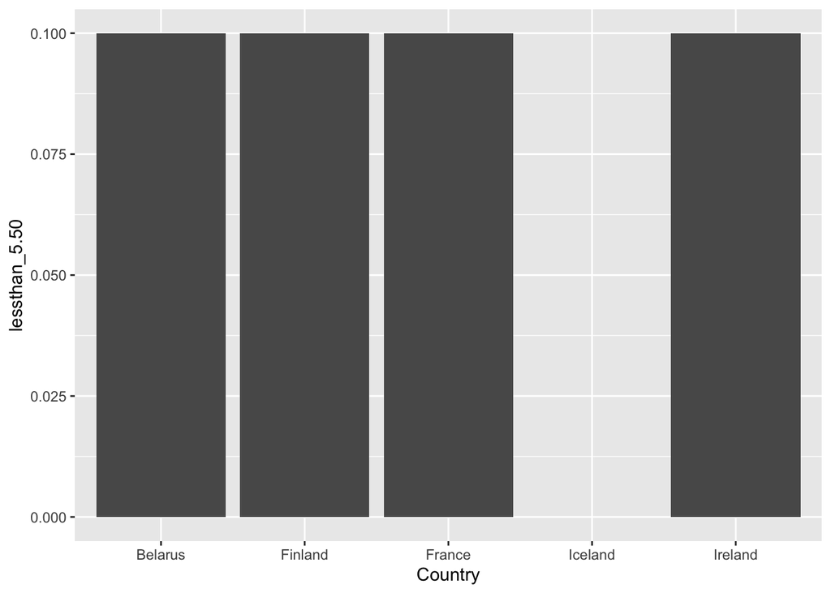

```r
## Create q4_data with countries with the lowest percentage of the population having an income of less than $5.50 per day
q4_data <- data3 %>% select(Country, lessthan_5.50, lessthan_1.90, lessthan_3.20) %>% group_by(Country) %>% arrange(lessthan_5.50)
q4_data <- head(q4_data, n = 5)
## Belarus, Finland, France, Iceland and Ireland have lowest percentage of the population having an income of less than $5.50 per day
## comparing this countries with less than 1.90$ or 3.20$ per day population is 0% for living less than $1.90/day while for living on 5.50 and 3.20$ per day is between 0 to 0.1%
ggplot(q4_data, aes(Country, lessthan_5.50)) + geom_bar(stat = "identity")
```

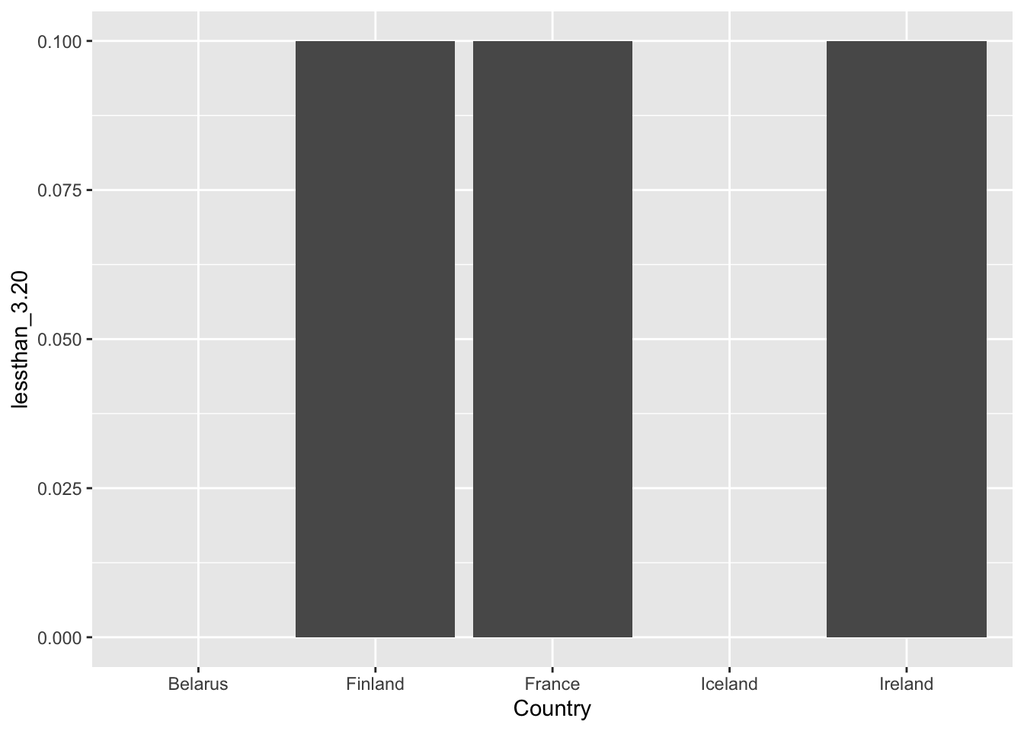

```r
ggplot(q4_data, aes(Country, lessthan_3.20)) + geom_bar(stat = "identity")
```